# Analysis of MET500 data

This document details the analysis of rna-seq data from the [MET500 project](https://met500.path.med.umich.edu/).

## Setting up the environment

These are packages you will need for this notebook. For exact versions used, please refer to the session info at the bottom of this notebook.

```r
##########################################################################################
library('tidyverse')
library('vroom')
library('ggplot2')
library('RColorBrewer')
```

I want to set a base directory that we can use as a link to the directory where we will do most of the work. I use two directories here because the Workspace is what is pushed to GitHub and contains scripts and plot files, but the Repository is where more of the big data is stored that does not get pushed.

```r
##########################################################################################
generalDatasets = 'C:/Users/chughes/Documents/bccrc/projectsRepository/generalDatasets'
baseWorkspace = 'C:/Users/chughes/Documents/bccrc/projectsWorkspace/sorensenLab/relatedToDlg2'
baseRepository = 'C:/Users/chughes/Documents/bccrc/projectsRepository/sorensenLab/relatedToDlg2'
#generalDatasets = 'C:/Users/chris/OneDrive/Documents/bccrc/projectsRepository/generalDatasets'
#baseWorkspace = 'C:/Users/chris/OneDrive/Documents/bccrc/projectsWorkspace/sorensenLab/relatedToYbx1'
#baseRepository = 'C:/Users/chris/OneDrive/Documents/bccrc/projectsRepository/sorensenLab/relatedToYbx1'
```

## Data processing

```r
##########################################################################################
sampleInfo = read_tsv(paste(generalDatasets, '/met500_pmid28783718/M.meta.plus.txt', sep = ''))
```

Read in the rna data and reshape it. This is a huge dataset, so you just have to take your gene of interest individually.

```r
##########################################################################################
rna = vroom(paste(generalDatasets, '/met500_pmid28783718/M.mx.txt.gz', sep = '')) %>%
  filter(grepl('ENSG00000150672', sample)) %>%
  pivot_longer(cols = `ES_5001-capt-SI_5013-C0LAMACXX`:`TP_2156-capt-SI_12477-C7G91ANXX`, names_to = 'Sample_id', values_to = 'fpkm') %>%
  mutate('expression' = log2(fpkm + 1)) %>%
  left_join(sampleInfo) %>%
  filter(!is.na(tissue))
```

```
Rows: 20,979
Columns: 869
chr [  1]: sample
dbl [868]: ES_5001-capt-SI_5013-C0LAMACXX, ES_5004-capt-SI_5834-C19KEACXX, ES_5004-poly-SI_5767-C19KEACXX, ES_5005-capt-SI_5505-D130HACXX, ES_5005-poly-SI_5486-D12YGACXX, MO_1001-pol...

Pass a specification to the `col_types` argument to quiet this message
```

Make a plot for DLG2 across the tissue column.

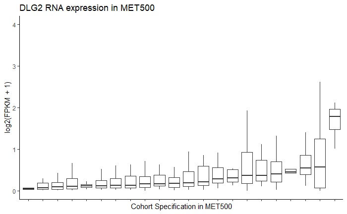

```r
##########################################################################################
ggplot(rna, aes(x = reorder(cohort, expression, median, na.rm = TRUE), expression)) +
  geom_boxplot(size = 0.5, outlier.shape = NA) +
  labs(x = 'Cohort Specification in MET500', y = 'log2(FPKM + 1)', title = 'DLG2 RNA expression in MET500') +
  scale_y_continuous(limits = c(0,4), breaks = seq(0,4,1)) +
  theme_classic() +
  theme(axis.text.x = element_blank())
ggsave(paste(baseRepository, '/database20210203_met500Dlg2Expression/boxplot_dlg2RnaExpressionCohortMet500.pdf', sep = ''),
       height = 4, width = 4, useDingbats = FALSE)
```

Want to make another plot based on the biopsy site to see if other brain samples are high or not.

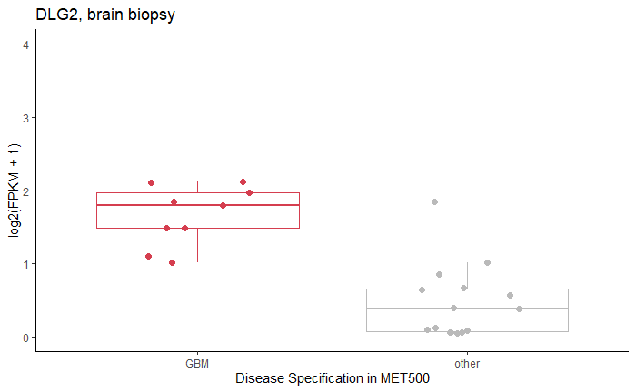

```r
##########################################################################################
brain = rna %>%
  filter(biopsy_tissue == 'brain') %>%
  mutate(disease = ifelse(cohort == 'GBM', 'GBM', 'other'))

##
ggplot(brain, aes(x = disease, expression, color = disease)) +
  geom_boxplot(size = 0.5, outlier.shape = NA) +
  geom_point(size = 2, position = position_jitterdodge()) +
  scale_color_manual(values = c(brewer.pal(8,'Spectral')[1], brewer.pal(11,'RdGy')[8])) +
  labs(x = 'Disease Specification in MET500', y = 'log2(FPKM + 1)', title = 'DLG2, brain biopsy') +
  scale_y_continuous(limits = c(0,4), breaks = seq(0,4,1)) +
  theme_classic() +
  theme(legend.position = 'none')
ggsave(paste(baseRepository, '/database20210203_met500Dlg2Expression/boxplot_dlg2RnaExpressionBrainMet500.pdf', sep = ''),
       height = 4, width = 2, useDingbats = FALSE)
```

## Session info

```r
##########################################################################################
sessionInfo()
```

[output not shown]